# Anderson-Darling Test

Lillian Holden

2023-10-19

## Anderson Darling Introduction

#### - H0 is the data that follows a specific distribution

#### - HA is the data that does not follow the specific distribution

#### The equation is as follows:

#### - A^2 = -N-S

#### - where S=N∑i=1((2i−1)/N)(lnF(Yi)+ln(1−F(YN+1−i))

#### - F is the cumulative distribution function of the specified distribution.

#### - Yi is the ordered data.

#### The test is useful to test normality which is common for regression, ANOVA, t-tests and more. The data sets need to be greater than 7, but are advised to be greater than 20.

#### The Anderson Darling Test starts with a null statement that your data is not statistically different than normal. The alternate statement is that it is different from normal. The results you will get will suggest you can either reject the null, or fail to reject the null. The test rejects the null hypothesis of normality when the p-value is less than or equal to 0.05 and accepts the null hypothesis (faults to reject the null) if it is greater than 0.05.

### Packages to Install

```r
#install.packages("nortest")
library(nortest)
```

## Using the Anderson-Darling Test with Preset Normal Distribution Data Known as “chickwts”

### Description of the Data Set: Newly hatched chicks were randomly allocated into six groups, and each group was given a different feed supplement. Their weights in grams after six weeks are given along with feed types. (https://www.rdocumentation.org/packages/datasets/versions/3.6.2/topics/chickwts)

```r
set.seed(1)
d <- chickwts
head(d)
```

```
##   weight      feed
## 1    179 horsebean
## 2    160 horsebean
## 3    136 horsebean
## 4    227 horsebean
## 5    217 horsebean
## 6    168 horsebean
```

### Select a The Weight Variable to Test

```r
a <- d$weight
a
```

```
##  [1] 179 160 136 227 217 168 108 124 143 140 309 229 181 141 260 203 148 169 213
## [20] 257 244 271 243 230 248 327 329 250 193 271 316 267 199 171 158 248 423 340
## [39] 392 339 341 226 320 295 334 322 297 318 325 257 303 315 380 153 263 242 206
## [58] 344 258 368 390 379 260 404 318 352 359 216 222 283 332
```

### Determining the A Value Step by Step Needed to Determine the AA Value

```r
x <- sort(a[complete.cases(a)]) #a is the data set that you want to test
n <- length(x) #length must be greater than 7
logp1 <- pnorm((x - mean(x))/sd(x), log.p = TRUE)
logp2 <- pnorm(-(x - mean(x))/sd(x), log.p = TRUE)
h <- (2 * seq(1:n) - 1) * (logp1 + rev(logp2))
A <- -n - mean(h)
A # The A value is computed
```

```
## [1] 0.4648545
```

### Determining the AA Value Needed to Determine the P Value

```r
AA <- (1 + 0.75/n + 2.25/n^2) * A
AA #The AA value is computed
```

```
## [1] 0.4699724
```

### Determining the P Value Step by Step

### Criteria for Determining the P Value

- Use this if AA > 10 pval <- 3.7e-24
- Use this if AA < 0.2 pval <- 1 - exp(-13.436 + 101.14 * AA - 223.73 * AA^2
- Use this if AA < 0.34  
  pval <- 1 - exp(-8.318 + 42.796 * AA - 59.938 * AA^2
- Use this if AA < 0.6 pval <- exp(0.9177 - 4.279 * AA - 1.38 * AA^2
- Use this if AA < 10 pval <- exp(1.2937 - 5.709 * AA + 0.0186 * AA^2
- Use the AA Value to Determine the P Value

### Using the AA Value to Determine the P Value

```r
pval <- exp(1.2937 - 5.709 * AA + 0.0186 * AA^2)
pval #The P Value is computed
```

```
## [1] 0.2502576
```

It can be concluded that the weight in chickwts is normally distributed because the p value is greater than 0.05.

### Challenge 1

Determine the A, AA, and P values of a sample of the chickwts data set. Compare the data of two diff variables. Are they both originating from normal distribution? How do you know this?

```r
set.seed(1)
b <- sample(a, size=71, replace=TRUE, prob=NULL) #I chose 71 because that is the lenth of the initial data set
b
```

```
##  [1] 216 392 179 171 320 141 258 303 244 153 108 423 423 171 295 199 158 283 226
## [20] 340 257 250 257 295 283 339 295 248 283 392 303 226 168 230 267 141 160 334
## [39] 169 271 318 283 283 181 339 318 243 193 181 271 250 318 199 334 244 316 148
## [58] 318 404 368 303 171 140 179 320 258 327 260 344 193 230
```

### Determine the A Value

```r
x <- sort(b[complete.cases(b)]) #a is the data set that you want to test, complete.cases() is for removing missing values from a vector
n <- length(x) #length must be greater than 7
logp1 <- pnorm((x - mean(x))/sd(x), log.p = TRUE)
logp2 <- pnorm(-(x - mean(x))/sd(x), log.p = TRUE)
h <- (2 * seq(1:n) - 1) * (logp1 + rev(logp2))
A <- -n - mean(h)
A # The A value is computed
```

```
## [1] 0.5180958
```

### Determining the AA Value

```r
AA <- (1 + 0.75/n + 2.25/n^2) * A
AA #The AA value is computed
```

```
## [1] 0.5237999
```

### Determine Which Equation to Use for the p Value based on the Criteria of AA

```r
pval <- exp(0.9177 - 4.279 * AA - 1.38 * AA^2)
pval
```

```
## [1] 0.1822702
```

## Perform the Anderson Darling Test on the Sample of Data using the ad.test() built in function

### Creating a function that is normally distributed

```r
set.seed(1) #Use the set.seed() function to allow the data to repeatable
ndistribution <- rnorm(100, 25, 1) #The rnorm() function generates a random sample with a default mean of 0 and standard deviation of 1
ndistribution
```

```
##   [1] 24.37355 25.18364 24.16437 26.59528 25.32951 24.17953 25.48743 25.73832
##   [9] 25.57578 24.69461 26.51178 25.38984 24.37876 22.78530 26.12493 24.95507
##  [17] 24.98381 25.94384 25.82122 25.59390 25.91898 25.78214 25.07456 23.01065
##  [25] 25.61983 24.94387 24.84420 23.52925 24.52185 25.41794 26.35868 24.89721
##  [33] 25.38767 24.94619 23.62294 24.58501 24.60571 24.94069 26.10003 25.76318
##  [41] 24.83548 24.74664 25.69696 25.55666 24.31124 24.29250 25.36458 25.76853
##  [49] 24.88765 25.88111 25.39811 24.38797 25.34112 23.87064 26.43302 26.98040
##  [57] 24.63278 23.95587 25.56972 24.86495 27.40162 24.96076 25.68974 25.02800
##  [65] 24.25673 25.18879 23.19504 26.46555 25.15325 27.17261 25.47551 24.29005
##  [73] 25.61073 24.06590 23.74637 25.29145 24.55671 25.00111 25.07434 24.41048
##  [81] 24.43133 24.86482 26.17809 23.47643 25.59395 25.33295 26.06310 24.69582
##  [89] 25.37002 25.26710 24.45748 26.20787 26.16040 25.70021 26.58683 25.55849
##  [97] 23.72341 24.42673 23.77539 24.52660
```

```r
ad.test(ndistribution)
```

```
##
##  Anderson-Darling normality test
##
## data:  ndistribution
## A = 0.16021, p-value = 0.9471
```

### Plotting the Data

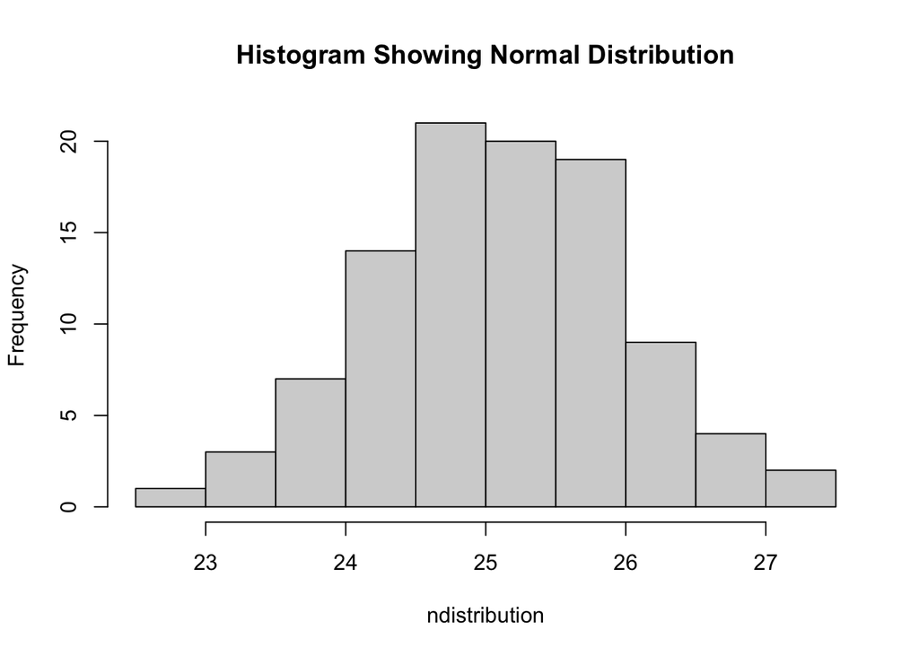

```r
hist(ndistribution, main = "Histogram Showing Normal Distribution")
```

### Challenge 2

```r
set.seed(1)
nodistribution <- rpois(100, 25)
nodistribution
```

```
##   [1] 21 31 31 27 17 27 28 27 23 32 26 21 23 22 24 29 29 27 29 28 25 15 27 30 21
##  [26] 22 23 22 26 24 18 29 22 30 28 24 23 28 27 21 17 28 24 29 26 21 21 32 34 23
##  [51] 19 18 37 24 28 25 21 17 32 25 35 27 21 24 28 30 25 24 20 22 31 28 23 22 26
##  [76] 30 23 26 26 22 25 20 32 27 18 26 29 28 21 20 19 33 28 29 26 33 21 25 25 16
```

```r
ad.test(nodistribution)
```

```
##
##  Anderson-Darling normality test
##
## data:  nodistribution
## A = 0.34642, p-value = 0.4751
```

### Plotting the Data

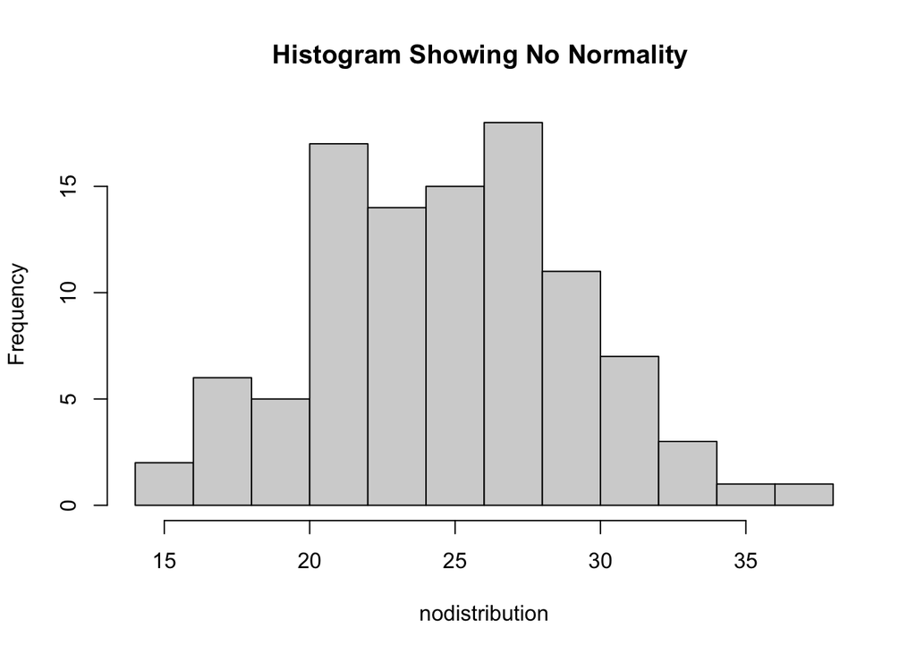

```r
hist(nodistribution, main= "Histogram Showing No Normality ")
```

### Shortcut to Creating Data Sets and Using ad.test() all at once

```r
ad.test(rnorm(100, mean = 5, sd = 3))
```

```
##
##  Anderson-Darling normality test
##
## data:  rnorm(100, mean = 5, sd = 3)
## A = 0.52388, p-value = 0.178
```

Normally distributed p-value >0.05

```r
ad.test(rpois(100,5))
```

```
##
##  Anderson-Darling normality test
##
## data:  rpois(100, 5)
## A = 1.2168, p-value = 0.003419
```

Not normally distributed p-value <0.05